# Intro to Data Science Final Project

## 4.5 Random Forest

We use this model a regularization model, to reduce variance error by reducing the important of less important predictors. It is a bagging algorithm which considers each split and divides it into only useful predictors - It uses two hyper paramaters `mtry` which considers x predictors in each split (it can be tuned to optimal value of useful predictors. and `min_n` to stop spliting the data

```r
# For missing values inside the dependent variable
remit_train_clean <- remit_train |>
  filter(!is.na(remittances_gdp))

# Smaller CV for run time optimization
rf_folds <- vfold_cv(remit_train_clean, v = 5)

## Given the high degree of missingness a recipe that accounts for nas will avoid it from breaking down using median imputation.
recipe_alt <-
  recipe(remittances_gdp ~ stock + gdp_per + gdp_lag + unemployment +
         dist_cap + terror + deportations + deportations_lag +
         internet + inflation + country_name,
  data = remit_train_clean) |>
update_role(country_name, new_role = "id") |>
step_impute_median(all_numeric_predictors()) |>
step_mutate(gdp_per = log(gdp_per + 1)) |>
step_normalize(all_numeric_predictors())

bake(prep(recipe_alt, training = remit_train_clean), new_data = remit_train_clean)
```

```
# A tibble: 3,292 × 12
     stock gdp_per gdp_lag unemployment dist_cap terror deportations
     <dbl>   <dbl>   <dbl>        <dbl>    <dbl>  <dbl>        <dbl>
 1 -0.163   1.00    -0.414        1.59    -0.473 -1.20        -0.155
 2 -0.163  -1.31    -0.615       -0.517    1.13  -0.288       -0.161
 3 -0.0870 -0.0360  -0.409        0.756    0.240  0.627       -0.145
 4 -0.163   1.67     2.28        -0.471   -2.18  -0.288       -0.142
 5  0.145   0.0499  -0.443        0.373   -0.226  0.627       -0.150
 6 -0.163  -0.177   -0.475        0.388   -0.465 -0.288       -0.155
 7 -0.163   0.112   -0.378        0.652   -0.112 -0.288       -0.155
 8 -0.0916 -0.559   -0.537       -0.968    1.51  -0.288       -0.142
 9 -0.163   1.37     1.22         1.14     1.41  -0.288       -0.161
10 -0.241   0.346   -0.250       -0.488    0.283  0.627       -0.158
# ℹ 3,282 more rows
# ℹ 5 more variables: deportations_lag <dbl>, internet <dbl>, inflation <dbl>,
#   country_name <chr>, remittances_gdp <dbl>
```

```r
## Creating a Random Forest Model set up for tuning
rf_mod <- rand_forest(
  trees = tune(),
  mtry = tune(),
  min_n = tune()) |>
  set_mode(mode = "regression") |>
  set_engine(engine = "ranger",
             importance = "impurity",
             num.threads = 4)

## Creating a workflow. Need to use alternative specific because it accounts for missingness which will lead the model to fail.
rf_wf <- workflow() |>
  add_recipe(recipe_alt) |>
  add_model(rf_mod)

## Finalize parameters

rf_params <- rf_wf |>
  extract_parameter_set_dials() |>
  finalize(remit_train_clean)

rf_params


## tuning grid
rf_grid <- grid_max_entropy(
  rf_params,
  size = 20 )

## Tuning it within cross validation using our hyperparamters.
rf_tuned <- rf_wf |>
  tune_grid(
    resamples = rf_folds,
    grid = rf_grid,
    control = control_grid(save_pred = TRUE))

## Measuring the RMSE
rf_tuned |>
  collect_metrics()
```

```
# A tibble: 40 × 9
    mtry trees min_n .metric .estimator  mean     n std_err .config
   <int> <int> <int> <chr>   <chr>      <dbl> <int>   <dbl> <chr>
 1    19  1868    19 rmse    standard   3.77      5  0.537  Preprocessor1_Model…
 2    19  1868    19 rsq     standard   0.718     5  0.0420 Preprocessor1_Model…
 3    16  1054     3 rmse    standard   3.41      5  0.545  Preprocessor1_Model…
 4    16  1054     3 rsq     standard   0.772     5  0.0437 Preprocessor1_Model…
 5     8  1913    23 rmse    standard   3.87      5  0.546  Preprocessor1_Model…
 6     8  1913    23 rsq     standard   0.704     5  0.0411 Preprocessor1_Model…
 7    14  1724     3 rmse    standard   3.41      5  0.540  Preprocessor1_Model…
 8    14  1724     3 rsq     standard   0.772     5  0.0428 Preprocessor1_Model…
 9    15  1797    30 rmse    standard   4.04      5  0.527  Preprocessor1_Model…
10    15  1797    30 rsq     standard   0.671     5  0.0371 Preprocessor1_Model…
# ℹ 30 more rows
```

```r
rf_tuned |>
  show_best(metric = "rmse", n = 10)
```

```
# A tibble: 10 × 9
    mtry trees min_n .metric .estimator  mean     n std_err .config
   <int> <int> <int> <chr>   <chr>      <dbl> <int>   <dbl> <chr>
 1    14  1724     3 rmse    standard    3.41     5   0.540 Preprocessor1_Model…
 2    16  1054     3 rmse    standard    3.41     5   0.545 Preprocessor1_Model…
 3    13   319     8 rmse    standard    3.50     5   0.525 Preprocessor1_Model…
 4    13  1185    14 rmse    standard    3.66     5   0.541 Preprocessor1_Model…
 5     3  1582     7 rmse    standard    3.73     5   0.589 Preprocessor1_Model…
 6    19  1868    19 rmse    standard    3.77     5   0.537 Preprocessor1_Model…
 7     5    12     6 rmse    standard    3.77     5   0.494 Preprocessor1_Model…
 8    20  1048    22 rmse    standard    3.85     5   0.526 Preprocessor1_Model…
 9     8  1913    23 rmse    standard    3.87     5   0.546 Preprocessor1_Model…
10    16    23    22 rmse    standard    3.92     5   0.538 Preprocessor1_Model…
```

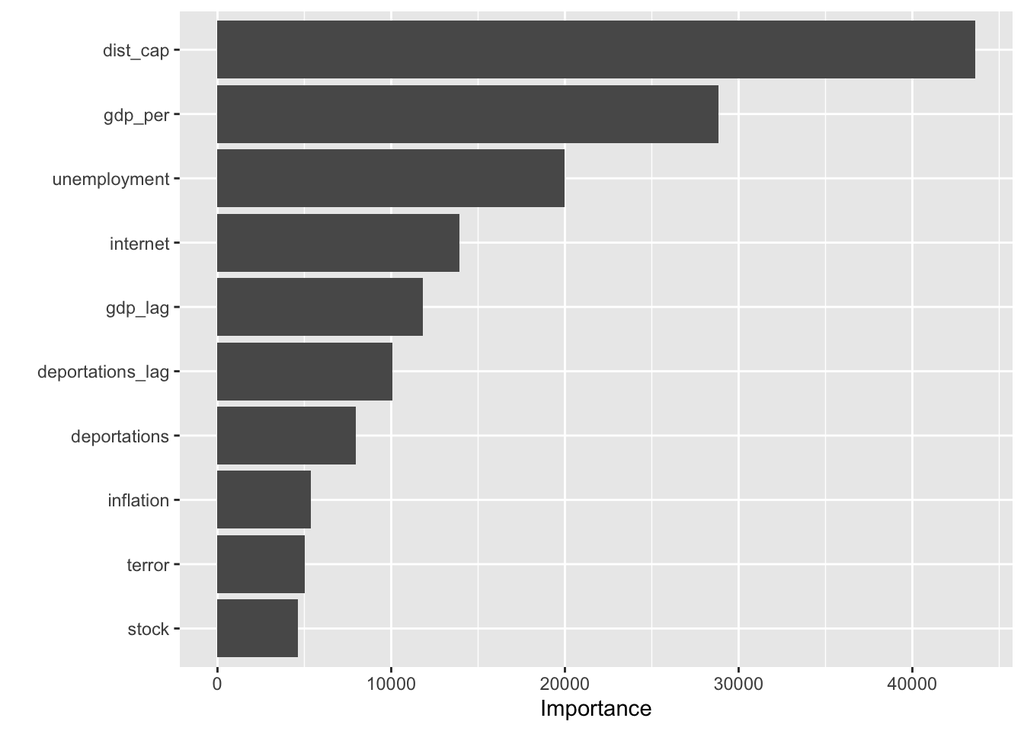

```r
## selecting the best specification and fit it to the full training data.
best_rf <-rf_tuned |>
  select_best(metric = "rmse")

final_rf_wf <- rf_wf |>
  finalize_workflow(best_rf)

final_rf_fit <- final_rf_wf |>
  fit(data = remit_train_clean)

# Variable importance
final_rf_fit |>
  extract_fit_parsnip() |>
  vip(num_features = 10)
```

## 4.6 K-Nearest Neighbors (KNN)

KNN predicts remittances by averaging the values of the K most similar country-year observations.

```r
## Create lagged variables by country
remit_train_lagged <- remit_train |>
  arrange(country_name, year) |>
  group_by(country_name) |>
  mutate(
    gdp_lag = lag(gdp_per),
    deportations_lag = lag(deportations)
  ) |>
  ungroup()

## Remove missing values
remit_train_clean_knn <- remit_train_lagged |>
  select(remittances_gdp, stock, gdp_per, unemployment, dist_cap,
         terror, deportations, internet, inflation, gdp_lag, deportations_lag) |>
  drop_na()

## Cross-validation setup
set.seed(20251211)
knn_folds <- vfold_cv(data = remit_train_clean_knn, v = 10, repeats = 5)

## Recipe: log transform and normalize
recipe_knn <-
  recipe(remittances_gdp ~ ., data = remit_train_clean_knn) |>
  step_mutate(gdp_per = log(gdp_per + 1)) |>
  step_normalize(all_numeric_predictors())

## Model: KNN with tunable K
knn_mod <-
  nearest_neighbor(neighbors = tune()) |>
  set_engine("kknn") |>
  set_mode("regression")

## Grid: test K from 1 to 99
knn_grid <- grid_regular(neighbors(range = c(1, 99)), levels = 10)

## Workflow
knn_workflow <-
  workflow() |>
  add_recipe(recipe_knn) |>
  add_model(knn_mod)

## Tune
knn_results <-
  knn_workflow |>
  tune_grid(
    resamples = knn_folds,
    grid = knn_grid,
    metrics = metric_set(rmse, rsq)
  )

## Results
knn_results |> collect_metrics()
```

```
# A tibble: 20 × 7
   neighbors .metric .estimator  mean     n std_err .config
       <int> <chr>   <chr>      <dbl> <int>   <dbl> <chr>
 1         1 rmse    standard   3.05     50 0.107   Preprocessor1_Model01
 2         1 rsq     standard   0.747    50 0.0145  Preprocessor1_Model01
 3        11 rmse    standard   3.07     50 0.0783  Preprocessor1_Model02
 4        11 rsq     standard   0.730    50 0.0116  Preprocessor1_Model02
 5        22 rmse    standard   3.35     50 0.0672  Preprocessor1_Model03
 6        22 rsq     standard   0.687    50 0.0100  Preprocessor1_Model03
 7        33 rmse    standard   3.58     50 0.0658  Preprocessor1_Model04
 8        33 rsq     standard   0.649    50 0.00946 Preprocessor1_Model04
 9        44 rmse    standard   3.77     50 0.0669  Preprocessor1_Model05
10        44 rsq     standard   0.614    50 0.00933 Preprocessor1_Model05
11        55 rmse    standard   3.91     50 0.0682  Preprocessor1_Model06
12        55 rsq     standard   0.584    50 0.00943 Preprocessor1_Model06
13        66 rmse    standard   4.03     50 0.0696  Preprocessor1_Model07
14        66 rsq     standard   0.560    50 0.00957 Preprocessor1_Model07
15        77 rmse    standard   4.12     50 0.0709  Preprocessor1_Model08
16        77 rsq     standard   0.540    50 0.00970 Preprocessor1_Model08
17        88 rmse    standard   4.20     50 0.0720  Preprocessor1_Model09
18        88 rsq     standard   0.523    50 0.00981 Preprocessor1_Model09
19        99 rmse    standard   4.26     50 0.0730  Preprocessor1_Model10
20        99 rsq     standard   0.509    50 0.00989 Preprocessor1_Model10
```

```r
knn_results |> show_best(metric = "rmse")
```

```
# A tibble: 5 × 7
  neighbors .metric .estimator  mean     n std_err .config
      <int> <chr>   <chr>      <dbl> <int>   <dbl> <chr>
1         1 rmse    standard    3.05    50  0.107  Preprocessor1_Model01
2        11 rmse    standard    3.07    50  0.0783 Preprocessor1_Model02
3        22 rmse    standard    3.35    50  0.0672 Preprocessor1_Model03
4        33 rmse    standard    3.58    50  0.0658 Preprocessor1_Model04
5        44 rmse    standard    3.77    50  0.0669 Preprocessor1_Model05
```

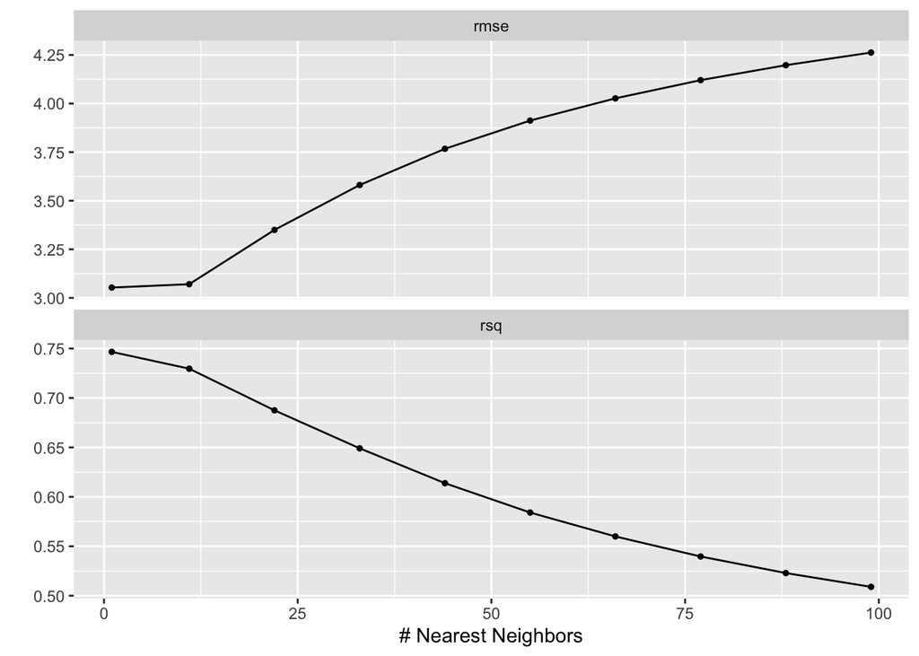

```r
knn_results |> autoplot()
```

```r
## Select best
best_k <- select_best(knn_results, metric = "rmse")
final_knn_wf <- knn_workflow |> finalize_workflow(best_k)
```

## 4.7 Which Model is the best?

```r
## Compare all models
tibble(
  Model = c("OLS", "Ridge", "LASSO", "Random Forest", "KNN"),
  Error = c(
    collect_metrics(lm_results) |> filter(.metric == "rmse") |> pull(mean),
    collect_metrics(ridge_res) |> filter(.metric == "rmse") |> inner_join(best_ridge, by = "penalty") |> pull(mean),
    collect_metrics(lasso_res) |> filter(.metric == "rmse") |> inner_join(best_lasso, by = "penalty") |> pull(mean),
    collect_metrics(rf_tuned) |> filter(.metric == "rmse") |> slice_min(mean) |> pull(mean),
    collect_metrics(knn_results) |> filter(.metric == "rmse") |> slice_min(mean) |> pull(mean)
  )
) |>
  arrange(Error)
```

```
# A tibble: 5 × 2
  Model         Error
  <chr>         <dbl>
1 KNN            3.05
2 Random Forest  3.41
3 LASSO          6.46
4 Ridge          6.46
5 OLS            6.47
```

Dot plot

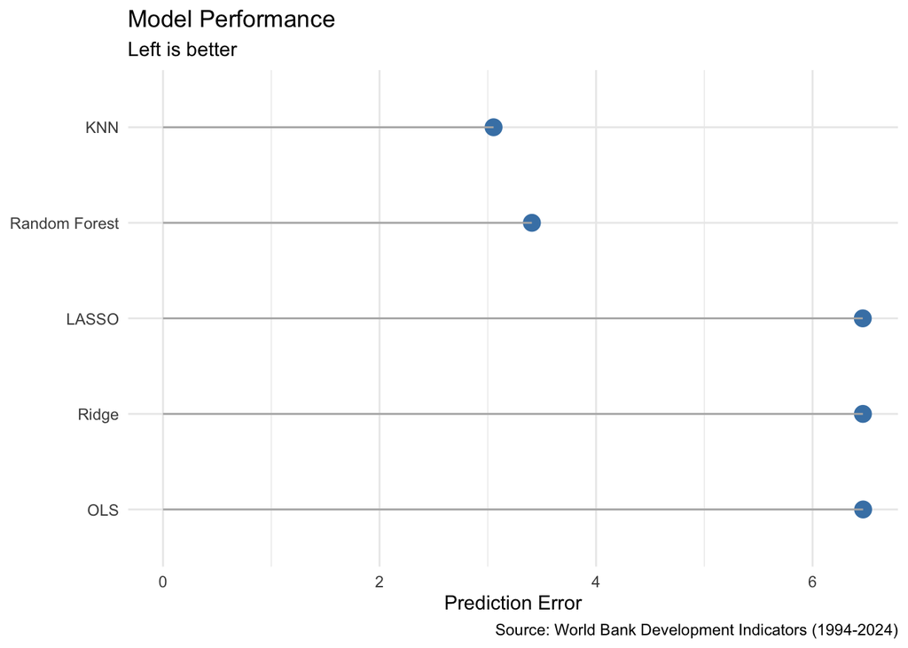

```r
tibble(
  Model = c("OLS", "Ridge", "LASSO", "Random Forest", "KNN"),
  Error = c(
    collect_metrics(lm_results) |> filter(.metric == "rmse") |> pull(mean),
    collect_metrics(ridge_res) |> filter(.metric == "rmse") |> inner_join(best_ridge, by = "penalty") |> pull(mean),
    collect_metrics(lasso_res) |> filter(.metric == "rmse") |> inner_join(best_lasso, by = "penalty") |> pull(mean),
    collect_metrics(rf_tuned) |> filter(.metric == "rmse") |> slice_min(mean) |> pull(mean),
    collect_metrics(knn_results) |> filter(.metric == "rmse") |> slice_min(mean) |> pull(mean)
  )
) |>
  ggplot(aes(x = Error, y = reorder(Model, -Error))) +
  geom_point(size = 4, color = "steelblue") +
  geom_segment(aes(x = 0, xend = Error, y = Model, yend = Model), color = "gray70") +
  labs(title = "Model Performance",
       subtitle = "Left is better",
       x = "Prediction Error",
       y = NULL,
      caption = "Source: World Bank Development Indicators (1994-2024)") +
  theme_minimal()
```

# STEP 5: Final Model Evaluation

The best model is **KNN** (lowest error: 3.05). Now we test it on completely new data.

## 5.1 Test the Best Model on New Data

```r
## Prepare test data
remit_test_clean_knn <- remit_test |>
  select(
    country_name, year,
    remittances_gdp, stock, gdp_per, unemployment, dist_cap,
    terror, deportations, internet, inflation, gdp_lag, deportations_lag
  ) |>
  drop_na()
```

```r
## Finalize & fit KNN on all training data
best_k <- select_best(knn_results, metric = "rmse")
final_knn_wf <- finalize_workflow(knn_workflow, best_k)

final_knn_fit <- final_knn_wf |>
  fit(data = remit_train_clean_knn)
```

```r
## Predict on test
test_predictions <- final_knn_fit |>
  augment(new_data = remit_test_clean_knn)
```

## 5.2 Country-Specific Performance & Residual Analysis

```r
## Look at countries of interest
countries_of_interest <- c(
  "Nicaragua", "El Salvador", "Honduras",
  "Guatemala", "Haiti", "India", "Mexico"
)
```

```r
## Calculate RMSE by country
rmse_tbl <- test_predictions |>
  filter(country_name %in% countries_of_interest) |>
  group_by(country_name) |>
  summarise(
    RMSE = rmse_vec(truth = remittances_gdp, estimate = .pred),
    MAE  = mae_vec(truth = remittances_gdp, estimate = .pred),
    R2   = rsq_vec(truth = remittances_gdp, estimate = .pred),
    Avg_Remittances_GDP = mean(remittances_gdp, na.rm = TRUE),
    n = n(),
    .groups = "drop"
  ) |>
  arrange(RMSE)

avg_perf_interest <- test_predictions |>
  filter(country_name %in% countries_of_interest) |>
  summarise(
    RMSE = rmse_vec(truth = remittances_gdp, estimate = .pred),
    MAE  = mae_vec(truth = remittances_gdp, estimate = .pred),
    R2   = rsq_vec(truth = remittances_gdp, estimate = .pred),
    n = n()
  )

rmse_tbl
```

```
# A tibble: 7 × 6
  country_name  RMSE    MAE     R2 Avg_Remittances_GDP     n
  <chr>        <dbl>  <dbl>  <dbl>               <dbl> <int>
1 Mexico       0.102 0.0944 0.996                 2.00     4
2 India        0.446 0.389  1                     3.39     2
3 Haiti        1.66  1.60   0.978                14.1      4
4 Nicaragua    2.60  1.83   0.604                10.3      5
5 Honduras     5.43  4.07   0.221                18.7      5
6 El Salvador  5.49  3.14   0.0815               19.7      4
7 Guatemala    6.73  5.75   1                    13.6      2
```

```r
avg_perf_interest
```

```
# A tibble: 1 × 4
   RMSE   MAE    R2     n
  <dbl> <dbl> <dbl> <int>
1  3.94  2.35 0.719    26
```

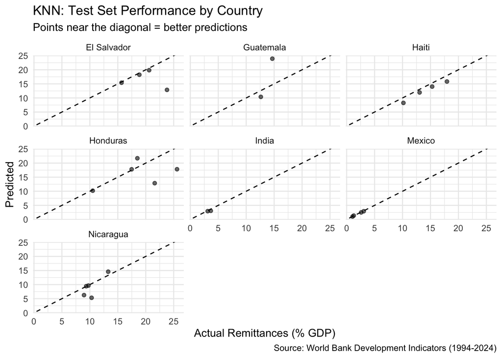

```r
## Visualize actual vs. predicted
test_predictions |>
  filter(country_name %in% countries_of_interest) |>
  ggplot(aes(x = remittances_gdp, y = .pred)) +
  geom_point(alpha = 0.6) +
  geom_abline(slope = 1, intercept = 0, linetype = "dashed") +
  facet_wrap(~ country_name) +
  labs(
    title = "KNN: Test Set Performance by Country",
    subtitle = "Points near the diagonal = better predictions",
    x = "Actual Remittances (% GDP)",
    y = "Predicted",
    caption = "Source: World Bank Development Indicators (1994-2024)") +
  theme_minimal()
```